# hw4

HyeongHwan Kim

2023-11-21

```r
library(ggplot2)
library(readr)
library(tibble)
```

```r
library(nycflights13)
library(purrr)
```

```r
library(dplyr)
library(modelr)
library(lubridate)
library(MASS)
library(forcats)
```

# Textbook 20.3.5

## Problem 5

What functions from the readr package allow you to turn a string into logical, integer, and double vector?

```r
parse_logical(c("true", "false"))
```

```
## [1]  TRUE FALSE
```

```r
parse_integer(c("1", "5", "4"))
```

```
## [1] 1 5 4
```

```r
parse_double(c("1.2", "12.16", "3.14"))
```

```
## [1]  1.20 12.16  3.14
```

# Textbook 20.4.6

## Problem 1

What does mean(is.na(x)) tell you about a vector x? What about sum(!is.finite(x))?

```r
x <- c(1, NA, 3, NA, 8)
mean(is.na(x))
```

```
## [1] 0.4
```

‘mean(is.na(x))’ means the proportion of NA data in vector x.

```r
x <- c(1, Inf, 3, Inf, 8, NA)
sum(!is.finite(x))
```

```
## [1] 3
```

‘sum(!is.finite(x))’ means the number of Inf or NA data in vector x.

## Problem 4

Create functions that take a vector as input and returns: 1. The last value. Should you use [ or [[?  
2. The elements at even numbered positions.  
3. Every element except the last value.  
4. Only even numbers (and no missing values).

```r
return_last_value <- function(X){
  return(x[length(x)])
}
x <- c(1, 2, 3, 4, 5)
return_last_value(x)
```

```
## [1] 5
```

```r
return_even_position <- function(X){
  return(x[seq(from = 2, to = length(x), by = 2)])
}
x <- c(1, 2, 3, 4, 5)
return_even_position(x)
```

```
## [1] 2 4
```

```r
return_except_last_value <- function(x){
  return(x[-length(x)])
}
x <- c(1, 2, 3, 4, 5)
return_except_last_value(x)
```

```
## [1] 1 2 3 4
```

```r
return_even_noNA <- function(x) {
  vec <- x[seq(from = 2, to = length(x), by = 2)]
  return(vec[!is.na(vec)])
}
x <- c(1, 2, NA, 4, 5, NA, 7, 8, 9, NA)
return_even_noNA(x)
```

```
## [1] 2 4 8
```

# Textbook 20.5.4

## Problem 2

What happens if you subset a tibble as if you’re subsetting a list? What are the key differences between a list and a tibble?

```r
my_tibble <- tibble(
  x = tibble(c(1, 2, 3), c(4, 5, 6), c(7, 8, 9)),
  y = c("A", "B", "C"),
  z = c(-2.8, 4.1, 9.7)
)
```

```r
my_list <- list(list(c(1, 2, 3), c(4, 5, 6), c(7, 8, 9)), c("A", "B", "C"), c(-2.8, 4.1, 9.7))
```

```r
my_tibble[[1]][[1]]
```

```
## [1] 1 2 3
```

```r
my_list[[1]][[1]]
```

```
## [1] 1 2 3
```

It works same as the list. However, when using tibble, we should set the length of each column to be same.

```r
my_tibble <- tibble(
  x = tibble(c(1, 2, 3), c(4, 5, 6), c(7, 8, 9)),
  y = c("A", "B"),
  z = c(-2.8, 4.1, 9.7)
)
```

```
## Error in `tibble()`:
## ! Tibble columns must have compatible sizes.
## • Size 3: Existing data.
## • Size 2: Column `y`.
## ℹ Only values of size one are recycled.
```

# Textbook 21.2.1

## Problem 1

Write for loops to: 1. Compute the mean of every column in mtcars.  
2. Determine the type of each column in nycflights13::flights.  
3. Compute the number of unique values in each column of iris.  
4. Generate 10 random normals from distributions with means of -10, 0, 10, and 100.  
Think about the output, sequence, and body before you start writing the loop.

```r
output <- vector("double", ncol(mtcars))
for(i in seq_along(mtcars)){
  output[[i]] <- mean(mtcars[[i]])
}
output
```

```
##  [1]  20.090625   6.187500 230.721875 146.687500   3.596563   3.217250
##  [7]  17.848750   0.437500   0.406250   3.687500   2.812500
```

```r
output <- vector("character", ncol(flights))
for(i in seq_along(flights)){
  output[[i]] <- typeof(flights[[i]])
}
output
```

```
##  [1] "integer"   "integer"   "integer"   "integer"   "integer"   "double"
##  [7] "integer"   "integer"   "double"    "character" "integer"   "character"
## [13] "character" "character" "double"    "double"    "double"    "double"
## [19] "double"
```

```r
output <- vector("integer", ncol(iris))
for(i in seq_along(iris)){
  output[[i]] <- length(unique(iris[[i]]))
}
output
```

```
## [1] 35 23 43 22  3
```

```r
mean_vec <- c(-10, 0, 10, 100)
output <- vector("list", length(mean_vec))
for(i in seq_along(mean_vec)){
  output[[i]] <- rnorm(mean = mean_vec[i], n = 10)
}
output
```

```
## [[1]]
##  [1]  -9.524405 -10.651507  -9.068606  -9.126126  -8.566919 -11.448846
##  [7]  -8.539400 -11.679023  -8.485314  -9.206583
##
## [[2]]
##  [1] -0.46729538 -2.11225543 -2.32267992  0.60020956  0.26501082  0.62766502
##  [7]  0.62628328 -0.46292711  0.06822834 -1.17331773
##
## [[3]]
##  [1]  9.867598  9.593913  9.591120  9.284565  9.169937 12.785655 10.626556
##  [8] 10.035345  9.607114  9.650497
##
## [[4]]
##  [1]  99.07757  98.76211 100.49486 100.63114  98.84640 100.31630 100.42579
##  [8] 100.04517  99.50281 101.92570
```

# Textbook 21.3.5

## Problem 3

```r
show_mean <- function(df){
  df <- df[, sapply(df, is.numeric)]
  mean_output <- list()
  col_names <- paste0(colnames(df), ":")
  col_names <- format(col_names, width = max(nchar(col_names)), justify = "left")
  for(i in seq_along(df)){
    output[[i]]<-paste(col_names[[i]], output[[i]] <- format(round(mean(df[[i]]), digits = 2)), sep = " ")
    print(output[[i]])
  }

}
show_mean(iris)
```

```
## [1] "Sepal.Length: 5.84"
## [1] "Sepal.Width:  3.06"
## [1] "Petal.Length: 3.76"
## [1] "Petal.Width:  1.2"
```

# Textbook 21.4.1

## Problem 1

Read the documentation for apply(). In the 2d case, what two for loops does it generalize?

```r
mat <- matrix(1:12, nrow = 3)
```

```r
apply(mat, MARGIN = 1, FUN = sum)
```

```
## [1] 22 26 30
```

```r
output_1 <- vector("integer", nrow(mat))
for(i in 1:nrow(mat)){
  output_1[i] <- sum(mat[i, ])
}
print(output_1)
```

```
## [1] 22 26 30
```

```r
apply(mat, MARGIN = 2, FUN = sum)
```

```
## [1]  6 15 24 33
```

```r
output_2 <- vector("integer", ncol(mat))
for(j in 1:ncol(mat)){
  output_2[j] <- sum(mat[,j ])
}
print(output_2)
```

```
## [1]  6 15 24 33
```

# Textbook 21.5.3

## Problem 1

Write code that uses one of the map functions to: 1. Compute the mean of every column in mtcars.  
2. Determine the type of each column in nycflights13::flights.  
3. Compute the number of unique values in each column of iris.  
4. Generate 10 random normals from distributions with means of -10, 0, 10, and 100.  
Think about the output, sequence, and body before you start writing the loop.

```r
map_dbl(mtcars, mean)
```

```
##        mpg        cyl       disp         hp       drat         wt       qsec
##  20.090625   6.187500 230.721875 146.687500   3.596563   3.217250  17.848750
##         vs         am       gear       carb
##   0.437500   0.406250   3.687500   2.812500
```

```r
map_chr(flights, typeof)
```

```
##           year          month            day       dep_time sched_dep_time
##      "integer"      "integer"      "integer"      "integer"      "integer"
##      dep_delay       arr_time sched_arr_time      arr_delay        carrier
##       "double"      "integer"      "integer"       "double"    "character"
##         flight        tailnum         origin           dest       air_time
##      "integer"    "character"    "character"    "character"       "double"
##       distance           hour         minute      time_hour
##       "double"       "double"       "double"       "double"
```

```r
map_int(iris, n_distinct)
```

```
## Sepal.Length  Sepal.Width Petal.Length  Petal.Width      Species
##           35           23           43           22            3
```

```r
map(c(-10, 0, 10, 100), ~rnorm(10, mean = .))
```

```
## [[1]]
##  [1]  -9.832636 -11.459481  -9.604985  -9.441505 -10.617056 -10.115581
##  [7] -10.260930 -12.126418 -10.572769 -10.088346
##
## [[2]]
##  [1]  0.90466775  0.06884442 -0.00267554 -0.75208589  0.43873198 -0.96334163
##  [7]  0.62864723  0.44091087  0.11235770  1.62923333
##
## [[3]]
##  [1]  9.159767  9.096164 10.337676  9.960864  9.933725 10.889602  9.750520
##  [8] 11.595866  9.479184  8.814642
##
## [[4]]
##  [1] 100.62710  99.84037  99.56981  99.97480  99.33654  99.68475 101.19455
##  [8]  99.85974  97.88303 101.22341
```

# Textbook 21.9.3

## Problem 2

Create an enhanced col_summary() that applies a summary function to every numeric column in a data frame.

```r
col_summary <- function(df, fun) {
  out <- vector("character", length(df))
  for (i in seq_along(df)) {
    if(is.numeric(df[,i]))
      out[i] <- paste(colnames(df)[i], fun(df[[i]]), sep = ": ")
  }
  out[out != ""]
}

col_summary(iris, mean)
```

```
## [1] "Sepal.Length: 5.84333333333333" "Sepal.Width: 3.05733333333333"
## [3] "Petal.Length: 3.758"            "Petal.Width: 1.19933333333333"
```

# Textbook 23.2.1

## Problem 1

One downside of the linear model is that it is sensitive to unusual values because the distance incorporates a squared term. Fit a linear model to the simulated data below, and visualise the results. Rerun a few times to generate different simulated datasets. What do you notice about the model?

```
##
## Call:
## lm(formula = y ~ x, data = sim1a)
##
## Residuals:
##     Min      1Q  Median      3Q     Max
## -6.1271 -1.1635 -0.2066  0.8827 15.1167
##
## Coefficients:
##             Estimate Std. Error t value Pr(>|t|)
## (Intercept)   5.0919     1.3563   3.754 0.000809 ***
## x             1.7739     0.2186   8.115 7.79e-09 ***
## ---
## Signif. codes:  0 '***' 0.001 '**' 0.01 '*' 0.05 '.' 0.1 ' ' 1
##
## Residual standard error: 3.439 on 28 degrees of freedom
## Multiple R-squared:  0.7017, Adjusted R-squared:  0.691
## F-statistic: 65.85 on 1 and 28 DF,  p-value: 7.788e-09
```

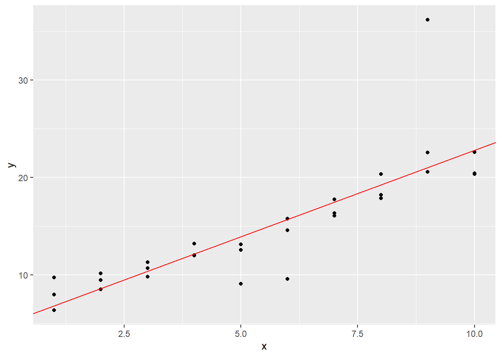

```
##
## Call:
## lm(formula = y ~ x, data = sim1a)
##
## Residuals:
##     Min      1Q  Median      3Q     Max
## -2.3061 -0.8981 -0.5080  0.5835  4.0198
##
## Coefficients:
##             Estimate Std. Error t value Pr(>|t|)
## (Intercept)  6.12208    0.60157   10.18 6.53e-11 ***
## x            1.48114    0.09695   15.28 4.13e-15 ***
## ---
## Signif. codes:  0 '***' 0.001 '**' 0.01 '*' 0.05 '.' 0.1 ' ' 1
##
## Residual standard error: 1.525 on 28 degrees of freedom
## Multiple R-squared:  0.8929, Adjusted R-squared:  0.8891
## F-statistic: 233.4 on 1 and 28 DF,  p-value: 4.126e-15
```

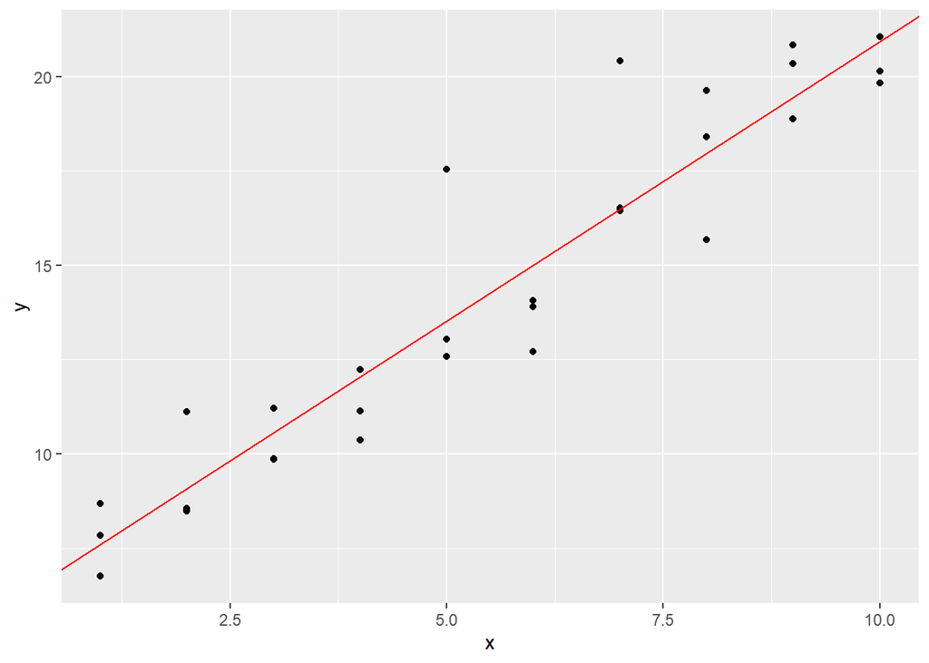

```
##
## Call:
## lm(formula = y ~ x, data = sim1a)
##
## Residuals:
##     Min      1Q  Median      3Q     Max
## -2.5619 -0.9807 -0.1468  0.8508  2.4401
##
## Coefficients:
##             Estimate Std. Error t value Pr(>|t|)
## (Intercept)  6.63508    0.52278   12.69 3.92e-13 ***
## x            1.35158    0.08425   16.04 1.20e-15 ***
## ---
## Signif. codes:  0 '***' 0.001 '**' 0.01 '*' 0.05 '.' 0.1 ' ' 1
##
## Residual standard error: 1.325 on 28 degrees of freedom
## Multiple R-squared:  0.9019, Adjusted R-squared:  0.8984
## F-statistic: 257.3 on 1 and 28 DF,  p-value: 1.204e-15
```

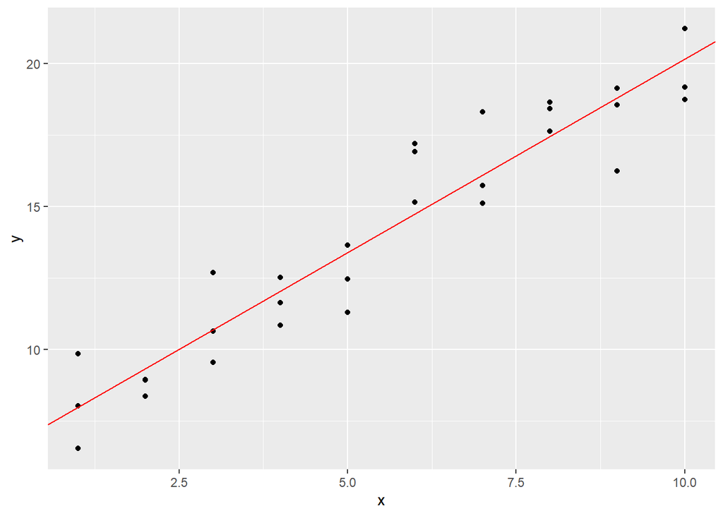

```
##
## Call:
## lm(formula = y ~ x, data = sim1a)
##
## Residuals:
##      Min       1Q   Median       3Q      Max
## -12.4414  -0.7079   0.7198   1.5476   6.0871
##
## Coefficients:
##             Estimate Std. Error t value Pr(>|t|)
## (Intercept)   6.7138     1.4096   4.763 5.30e-05 ***
## x             1.2321     0.2272   5.423 8.73e-06 ***
## ---
## Signif. codes:  0 '***' 0.001 '**' 0.01 '*' 0.05 '.' 0.1 ' ' 1
##
## Residual standard error: 3.574 on 28 degrees of freedom
## Multiple R-squared:  0.5123, Adjusted R-squared:  0.4949
## F-statistic: 29.41 on 1 and 28 DF,  p-value: 8.726e-06
```

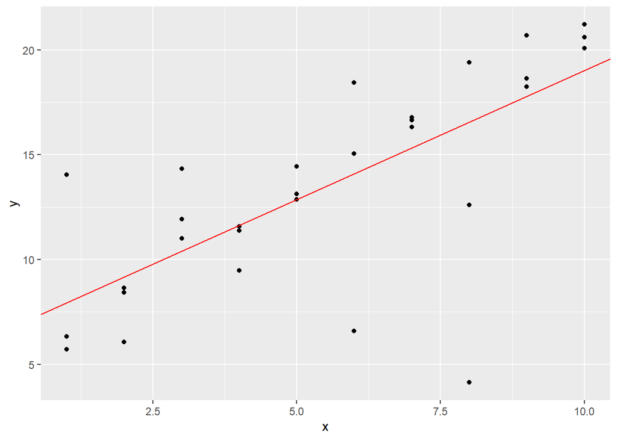

```
##
## Call:
## lm(formula = y ~ x, data = sim1a)
##
## Residuals:
##     Min      1Q  Median      3Q     Max
## -3.1727 -1.2603 -0.5759  0.6980  9.4722
##
## Coefficients:
##             Estimate Std. Error t value Pr(>|t|)
## (Intercept)   7.1282     0.9396   7.586  2.9e-08 ***
## x             1.4840     0.1514   9.800  1.5e-10 ***
## ---
## Signif. codes:  0 '***' 0.001 '**' 0.01 '*' 0.05 '.' 0.1 ' ' 1
##
## Residual standard error: 2.382 on 28 degrees of freedom
## Multiple R-squared:  0.7743, Adjusted R-squared:  0.7662
## F-statistic: 96.04 on 1 and 28 DF,  p-value: 1.501e-10
```

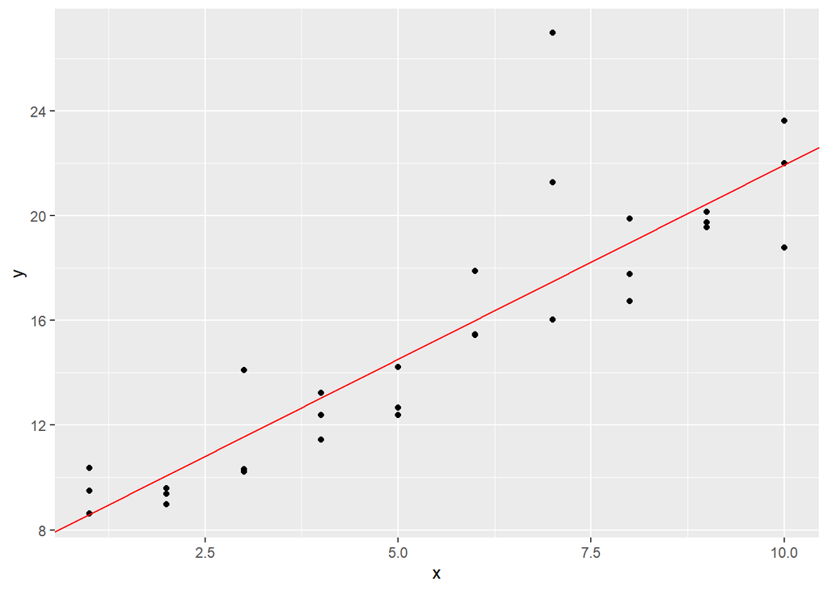

```
##
## Call:
## lm(formula = y ~ x, data = sim1a)
##
## Residuals:
##     Min      1Q  Median      3Q     Max
## -2.3195 -0.4298  0.1492  0.4829  3.3259
##
## Coefficients:
##             Estimate Std. Error t value Pr(>|t|)
## (Intercept)  6.03588    0.45970   13.13 1.73e-13 ***
## x            1.44769    0.07409   19.54  < 2e-16 ***
## ---
## Signif. codes:  0 '***' 0.001 '**' 0.01 '*' 0.05 '.' 0.1 ' ' 1
##
## Residual standard error: 1.166 on 28 degrees of freedom
## Multiple R-squared:  0.9317, Adjusted R-squared:  0.9292
## F-statistic: 381.8 on 1 and 28 DF,  p-value: < 2.2e-16
```

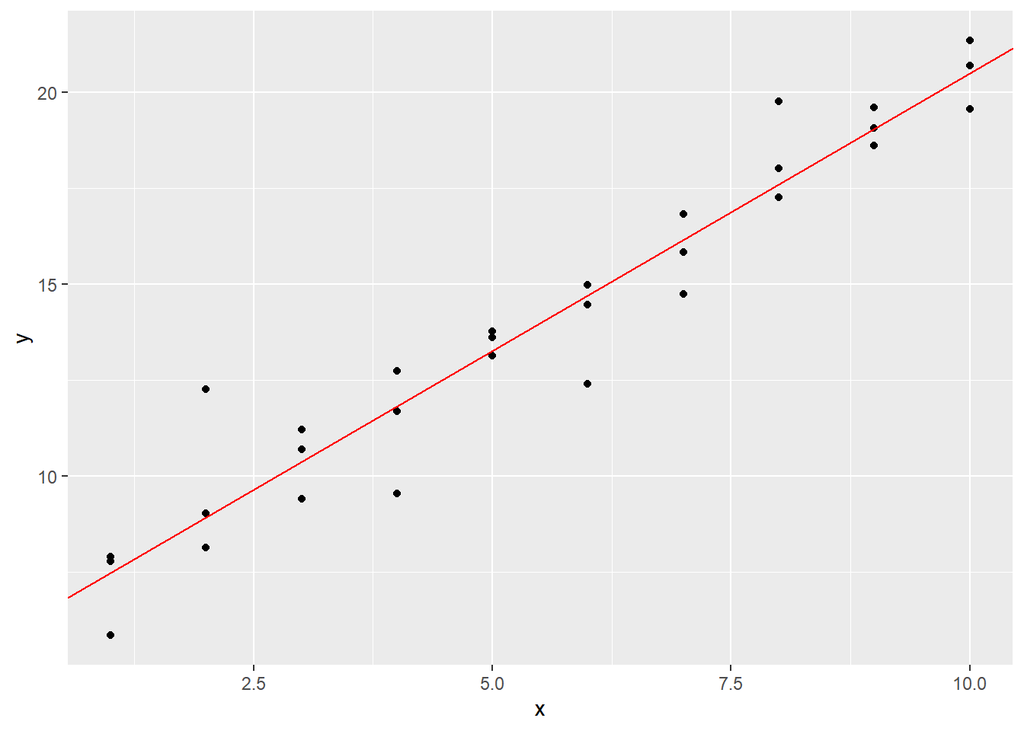

```
##
## Call:
## lm(formula = y ~ x, data = sim1a)
##
## Residuals:
##      Min       1Q   Median       3Q      Max
## -24.4270  -0.3538   0.9688   2.1932   7.1906
##
## Coefficients:
##             Estimate Std. Error t value Pr(>|t|)
## (Intercept)   3.5129     2.0748   1.693    0.102
## x             1.8608     0.3344   5.565 5.94e-06 ***
## ---
## Signif. codes:  0 '***' 0.001 '**' 0.01 '*' 0.05 '.' 0.1 ' ' 1
##
## Residual standard error: 5.261 on 28 degrees of freedom
## Multiple R-squared:  0.5252, Adjusted R-squared:  0.5082
## F-statistic: 30.97 on 1 and 28 DF,  p-value: 5.937e-06
```

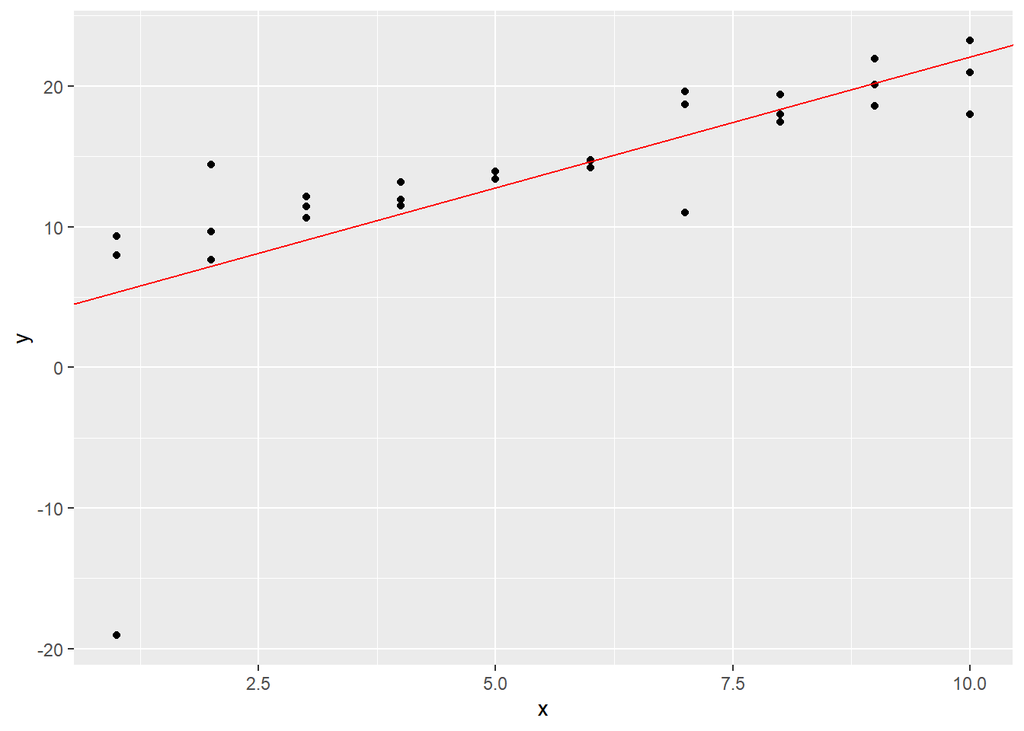

```
##
## Call:
## lm(formula = y ~ x, data = sim1a)
##
## Residuals:
##      Min       1Q   Median       3Q      Max
## -23.4553  -0.0721   0.9740   1.5086   2.6727
##
## Coefficients:
##             Estimate Std. Error t value Pr(>|t|)
## (Intercept)   4.8933     1.8247   2.682   0.0121 *
## x             1.6082     0.2941   5.468 7.72e-06 ***
## ---
## Signif. codes:  0 '***' 0.001 '**' 0.01 '*' 0.05 '.' 0.1 ' ' 1
##
## Residual standard error: 4.627 on 28 degrees of freedom
## Multiple R-squared:  0.5164, Adjusted R-squared:  0.4992
## F-statistic:  29.9 on 1 and 28 DF,  p-value: 7.721e-06
```

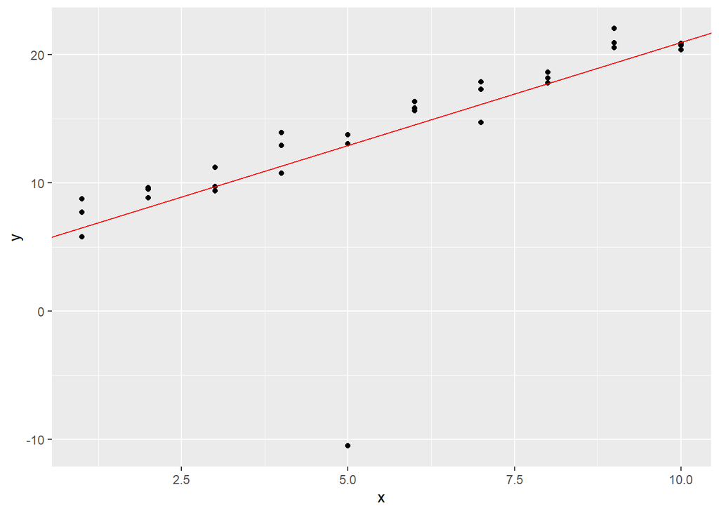

```
##
## Call:
## lm(formula = y ~ x, data = sim1a)
##
## Residuals:
##     Min      1Q  Median      3Q     Max
## -1.5226 -0.6351 -0.1636  0.3848  2.8369
##
## Coefficients:
##             Estimate Std. Error t value Pr(>|t|)
## (Intercept)  6.24918    0.40854    15.3    4e-15 ***
## x            1.48154    0.06584    22.5   <2e-16 ***
## ---
## Signif. codes:  0 '***' 0.001 '**' 0.01 '*' 0.05 '.' 0.1 ' ' 1
##
## Residual standard error: 1.036 on 28 degrees of freedom
## Multiple R-squared:  0.9476, Adjusted R-squared:  0.9457
## F-statistic: 506.3 on 1 and 28 DF,  p-value: < 2.2e-16
```

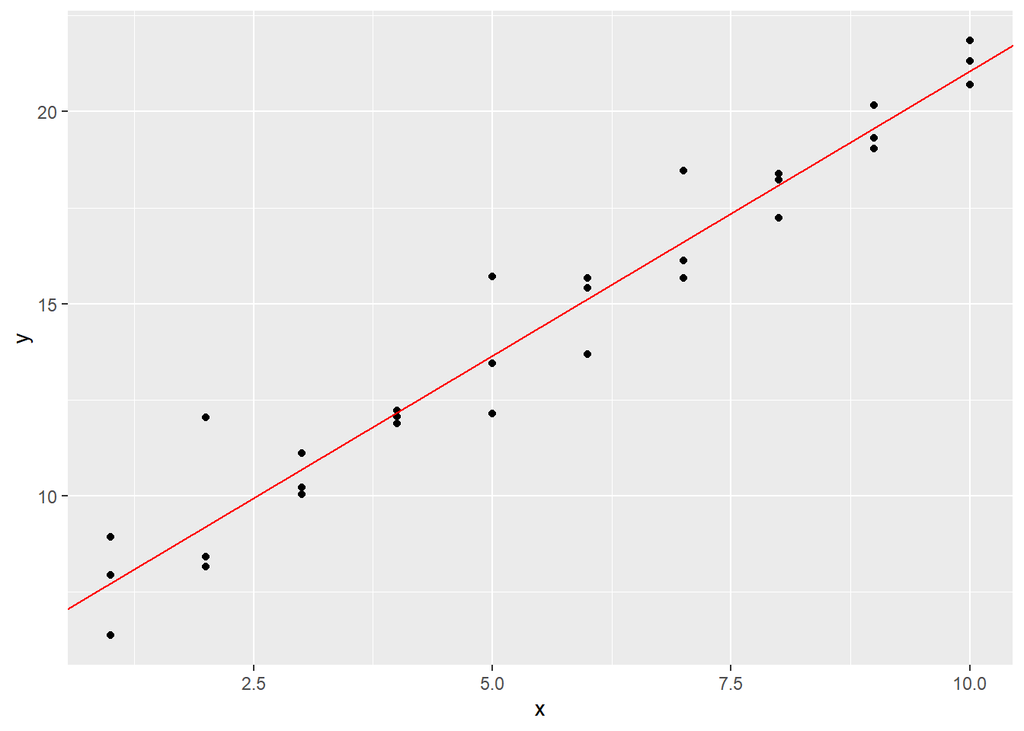

```
##
## Call:
## lm(formula = y ~ x, data = sim1a)
##
## Residuals:
##     Min      1Q  Median      3Q     Max
## -2.0555 -0.7438  0.2633  0.6484  2.0749
##
## Coefficients:
##             Estimate Std. Error t value Pr(>|t|)
## (Intercept)  5.53304    0.39534   14.00 3.64e-14 ***
## x            1.51434    0.06371   23.77  < 2e-16 ***
## ---
## Signif. codes:  0 '***' 0.001 '**' 0.01 '*' 0.05 '.' 0.1 ' ' 1
##
## Residual standard error: 1.002 on 28 degrees of freedom
## Multiple R-squared:  0.9528, Adjusted R-squared:  0.9511
## F-statistic: 564.9 on 1 and 28 DF,  p-value: < 2.2e-16
```

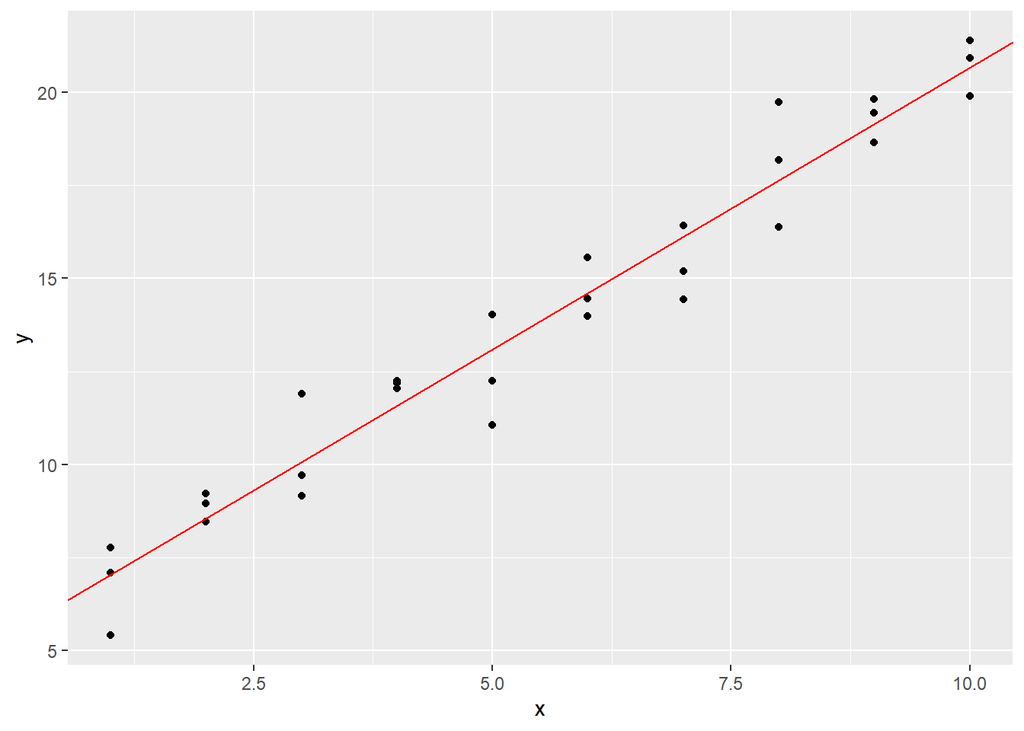

```r
set.seed(1589)
for(i in 1:10) {
  sim1a <- tibble(
    x = rep(1:10, each = 3),
    y = x * 1.5 + 6 + rt(length(x), df = 2)
  )

  lm_model <- lm(y ~ x, data = sim1a)
  print(summary(lm_model))

  print(ggplot(data = sim1a) +
  geom_point(mapping = aes(x = x, y = y)) +
  geom_abline(intercept = lm_model$coefficients[1], slope = lm_model$coefficients[2], col = "red")) +
  ggtitle(paste(lm_model$coefficients[1], lm_model$coefficients[2], sep = " "))
}
```

## Problem 2

One way to make linear models more robust is to use a different distance measure. For example, instead of root-mean-squared distance, you could use mean-absolute distance:

```r
model1 <- function(a, data) {
  a[1] + data$x * a[2]
}
```

```r
measure_distance <- function(mod, data) {
  diff <- data$y - model1(mod, data)
  mean(abs(diff))
}
```

Use optim() to fit this model to the simulated data above and compare it to the linear model.

```r
best <- optim(par = c(0, 0), fn = measure_distance, data = sim1a)
```

```r
lm_model <- lm(y ~ x, data = sim1a)
lm_model$coefficients
```

```
## (Intercept)           x
##    5.533035    1.514341
```

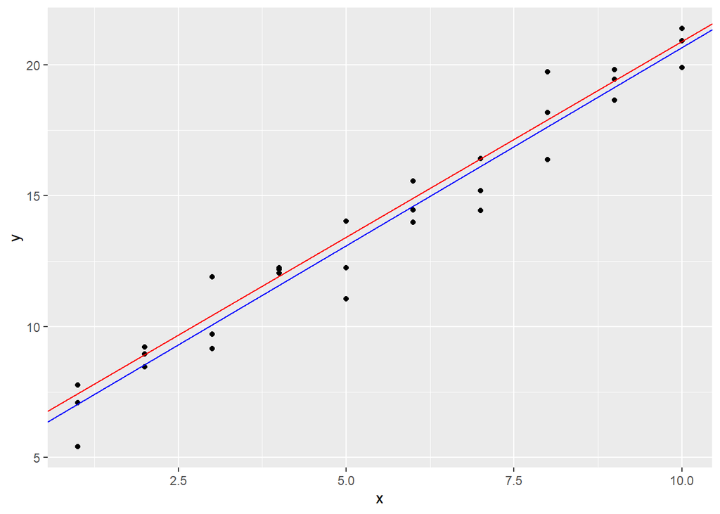

```r
ggplot(data = sim1a) +
  geom_point(mapping = aes(x = x, y = y)) +
  geom_abline(intercept = best$par[1], slope = best$par[2], col = "red") +
  geom_abline(intercept = lm_model$coefficients[1], slope = lm_model$coefficients[2], col = "blue")
```

The lines obtained from two methods are quite similar. Since we use L1-loss to optimize linear model, two lines are not same.

# Textbook 23.3.3

## Problem 1

Instead of using lm() to fit a straight line, you can use loess() to fit a smooth curve. Repeat the process of model fitting, grid generation, predictions, and visualisation on sim1 using loess() instead of lm(). How does the result compare to geom_smooth()?

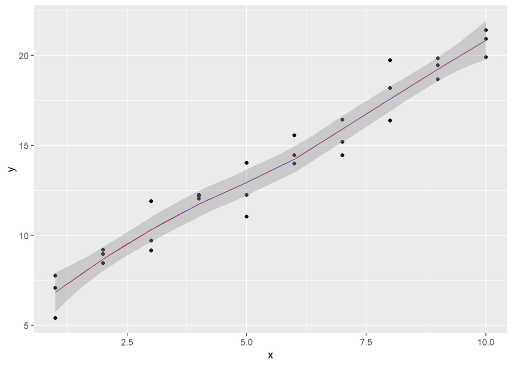

```r
loess_model <- loess(y ~ x, data = sim1a)

grid <- sim1a %>%
  data_grid(x)

grid <- grid %>%
  add_predictions(loess_model)

ggplot(data = sim1a) +
  geom_point(mapping = aes(x = x, y = y)) +
  geom_line(mapping = aes(x = x, y = pred), data = grid, color = "red") +
  geom_smooth(mapping = aes(x = x, y = y), linewidth = 0.01)
```

Two lines are exactly same.

# Textbook 23.4.5

## Problem 3

Using the basic principles, convert the formulas in the following two models into functions. (Hint: start by converting the categorical variable into 0-1 variables.)

```r
head(sim3, 3)
```

```
## # A tibble: 3 × 5
##      x1 x2      rep      y    sd
##   <int> <fct> <int>  <dbl> <dbl>
## 1     1 a         1 -0.571     2
## 2     1 a         2  1.18      2
## 3     1 a         3  2.24      2
```

```r
mod1 <- function(df) {
  variable_names <- c("x1")

  for(lv in levels(df$x2)[2:length(levels(df$x2))]){
    variable_name <- paste0("x2", lv)
    variable_names <- append(variable_names, variable_name)
    df[variable_name] <- ifelse(df$x2 == lv, 1, 0)
  }
  mod_y <- df$y
  df <- df[variable_names]
  mod <- lm(mod_y ~ as.matrix(df))
  return(mod)
}

my_lm_model <- mod1(sim3)
lm_model <- lm(y ~ x1 + x2, data = sim3)
my_lm_model
```

```
##
## Call:
## lm(formula = mod_y ~ as.matrix(df))
##
## Coefficients:
##      (Intercept)   as.matrix(df)x1  as.matrix(df)x2b  as.matrix(df)x2c
##           1.8717           -0.1967            2.8878            4.8057
## as.matrix(df)x2d
##           2.3596
```

```r
lm_model
```

```
##
## Call:
## lm(formula = y ~ x1 + x2, data = sim3)
##
## Coefficients:
## (Intercept)           x1          x2b          x2c          x2d
##      1.8717      -0.1967       2.8878       4.8057       2.3596
```

```r
# Two results are same.
```

```r
mod2 <- function(df) {
  variable_names <- c("x1")

  for(lv in levels(df$x2)[2:length(levels(df$x2))]){
    variable_name <- paste0("x2", lv)
    variable_names <- append(variable_names, variable_name)
    df[variable_name] <- ifelse(df$x2 == lv, 1, 0)
  }
  for(var in variable_names[2:length(variable_names)]){
    variable_name <- paste0("x1:", var)
    variable_names <- append(variable_names, variable_name)
    df[variable_name] <- df$x1 * df[var]
  }
  mod_y <- df$y
  df <- df[variable_names]
  mod <- lm(mod_y ~ as.matrix(df))
  return(mod)
}
my_lm_model <- mod2(sim3)
lm_model <- lm(y ~ x1 * x2, data = sim3)
my_lm_model
```

```
##
## Call:
## lm(formula = mod_y ~ as.matrix(df))
##
## Coefficients:
##         (Intercept)      as.matrix(df)x1     as.matrix(df)x2b
##             1.30124             -0.09302              7.06938
##    as.matrix(df)x2c     as.matrix(df)x2d  as.matrix(df)x1:x2b
##             4.43090              0.83455             -0.76029
## as.matrix(df)x1:x2c  as.matrix(df)x1:x2d
##             0.06815              0.27728
```

```r
lm_model
```

```
##
## Call:
## lm(formula = y ~ x1 * x2, data = sim3)
##
## Coefficients:
## (Intercept)           x1          x2b          x2c          x2d       x1:x2b
##     1.30124     -0.09302      7.06938      4.43090      0.83455     -0.76029
##      x1:x2c       x1:x2d
##     0.06815      0.27728
```

```r
# Two results are same.
```

# Textbook 24.2.3

## Problem 2

If log(price) = a_0 + a_1 * log(carat), what does that say about the relationship between price and carat?

It is equivalent as price = exp(a_0) * carat^a_1 That is to say price is proportional to carat^r.

# Textbook 24.3.5

## Problem 2

What do the three days with high positive residuals represent? How would these days generalise to another year?

```r
daily <- flights %>%
  mutate(date = make_date(year, month, day)) %>%
  group_by(date) %>%
  summarise(n = n())
daily <- daily %>%
  mutate(wday = wday(date, label = TRUE))
mod <- lm(n ~ wday, data = daily)
daily <- daily %>%
  add_residuals(mod)
```

```r
daily %>%
  slice_max(n = 3, resid)
```

```
## # A tibble: 3 × 4
##   date           n wday  resid
##   <date>     <int> <ord> <dbl>
## 1 2013-11-30   857 토    112.
## 2 2013-12-01   987 일     95.5
## 3 2013-12-28   814 토     69.4
```

They are all next weekend of the holiday. For example, 11/30 and 12/1 is next Saturday and Sunday of Thanksgiving day, and 12/28 is next Saturday of Christmas. So it can be generalized in terms of the holidays.

## Problem 4

Create a new wday variable that combines the day of week, term (for Saturdays), and public holidays. What do the residuals of that model look like?

```r
term <- function(date) {
  cut(date,
    breaks = ymd(20130101, 20130605, 20130825, 20140101),
    labels = c("spring", "summer", "fall")
  )
}

daily <- daily %>%
  mutate(term = term(date))
```

```r
public_holidays <- ymd(c("20130101", "20130121", "20130218", "20130527", "20130704", "20130902", "20131014", "20131111", "20131128", "20131225"))
```

```r
public_holidays
```

```
##  [1] "2013-01-01" "2013-01-21" "2013-02-18" "2013-05-27" "2013-07-04"
##  [6] "2013-09-02" "2013-10-14" "2013-11-11" "2013-11-28" "2013-12-25"
```

To strengthen the effect of the holiday, I added two more levels, “holiday_before” and “holiday_after”.

```r
daily <- daily %>%
  mutate(wday_new =
           case_when(date %in% public_holidays ~ "holiday",
                     date %in% (public_holidays - 1L) ~ "holiday_before",
                     date %in% (public_holidays + 1L) ~ "holiday_after",
                     wday == "토" ~ term,
                     TRUE ~ wday))
```

```r
new_model <- rlm(n ~ wday_new, data = daily)
```

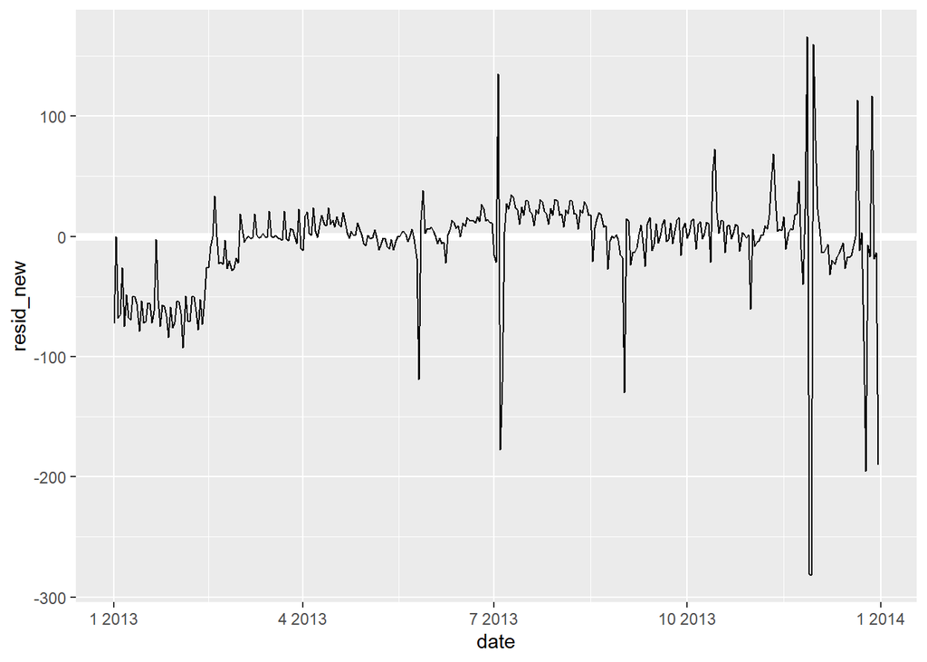

```r
daily <- daily %>%
  add_residuals(new_model, "resid_new")

daily %>% ggplot(aes(date, resid_new)) +
  geom_hline(yintercept = 0, size = 2, colour = "white") +
  geom_line()
```

## Problem 8

It’s a little frustrating that Sunday and Saturday are on separate ends of the plot. Write a small function to set the levels of the factor so that the week starts on Monday.

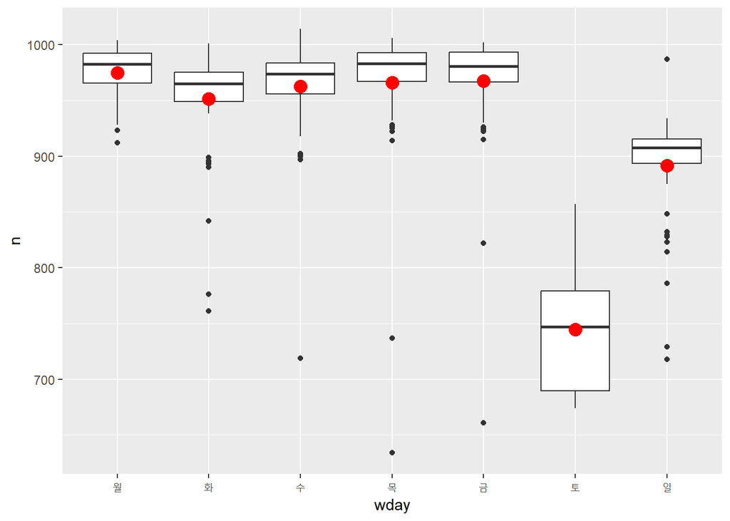

```r
change_level <- function(vec) {
  vec <- fct_relevel(vec, levels(vec)[-1])
  return(vec)
}

mod <- lm(n ~ wday, data = daily)

grid <- daily %>%
  data_grid(wday) %>%
  add_predictions(mod, "n")

daily %>%
  mutate(wday = change_level(wday)) %>%
  ggplot(daily, mapping = aes(x = wday, y = n)) +
  geom_boxplot() +
  geom_point(data = grid, colour = "red", size = 4)
```